Comparative Overview of  
Programming Languages  
for Data-Intensive Projects

Author: *Leo Osvald* `<losvald@purdue.edu>`

# Which programming languages?

- 3/4 languages with APIs for Spark (useful for data-intensive computing):
  - **Python** - a multi-paradigm language with a focus on *readability*
  - **R** - a *statistical* computing language
  - **Scala** - a *scalable* JVM language that meets functional and object-oriented
- **Go** (golang) - a pragmatic system language suitable for writing servers
  - one of the fastest growing languages (top 13, a winner in 2016/2009)
  - nearly as fast as C/C++, but easy to learn & master
  - used to write a number of recent production-grade **data tools**:
    - InfluxDB - scalable datastore for metrics, events & real-time analytics
    - Grafana - *beautiful monitoring and metric analytics & dashboards*
    - Prometheus - *monitoring system and time series database*
    - Docker, Kubernetes - *virtualization, container deployment & management*

Adapted from AIDA-light: *High-Throughput Named-Entity Disambiguation* by Dat Ba Nguyen et al., 2014

> Under **Fergie**, **United** won the **Premier League** title 13 times.

[figure not shown]

### Analyzing context within certain distance

Core computation:

```
def neighboring_word_freqs(message, max_dist=10):
    words = tokenize(message.text)
    return [
        ((word1, word2, idx2 - idx1), 1)
        for idx1, word1 in enumerate(words)
        for idx2, word2 in enumerate(words)
        if 1 <= abs(idx1 - idx2) <= max_dist]
```

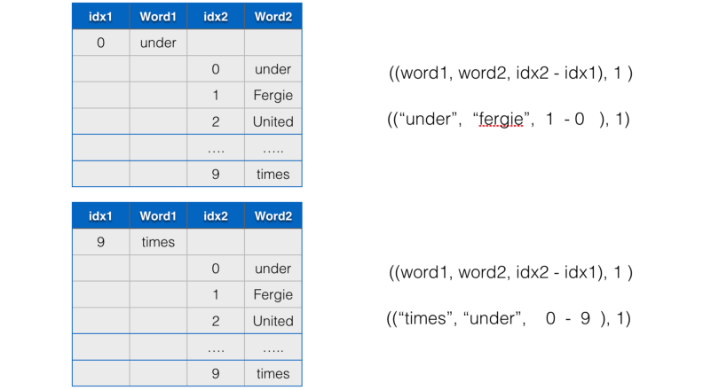

### Analyzing context within certain distance

Core computation (Python):

```
def neighboring_word_freqs(message, max_dist=10):
    words = tokenize(message.text)
    return [
        ((word1, word2, idx2 - idx1), 1)
        for idx1, word1 in enumerate(words)
        for idx2, word2 in enumerate(words)
        if 1 <= abs(idx1 - idx2) <= max_dist]
```

Py**Spark** job to **parallelize** it across the cluster:

```
df = spark_sql.read.json("twitter.json").query(
    "SELECT text WHERE lang='en'")
result = df.rdd\
           .flatMap(neighboring_word_freqs)\
           .reduceByKey(add)
for entry in result.toLocalIterator():
    (word1, word2, offset), freq = entry
    print(word1, word2, offset, entry)
```

## When it gets more complicated...

- generalize approach to **multiple** data sources that are
  - **heteregenous** (different treatment)
  - fetch data at **different rate**
- support different analyses
- **continuous delivery** of results

*Question*: Which languages to use for which parts?

# Common features of Python, R, Scala, Go

- popular in data science/analytics
- "batteries included" - huge standard libraries (stable)
- *automatic* **G**arbage **C**ollection (no need to explicitly manage memory)
- fully support *reflection*; inspection of properties at **run-time**
  - does a variable *currently* hold a text or a (bunch of) numbers?
  - can we iterate over contents of `x`, or can we call `x`
  - can we call `train` on an object that represents a `model`?
- easy to experiment with (no need to setup up a project/package):
  - Go code (including tests) can be **run as a script** (compile+run)
  - Python/R/Scala have **interactive shell** (can also run as a script)

# Differences in Building & Deployment

|  |  | Python | R | Scala | Go/C++ |
| --- | --- | --- | --- | --- | --- |
| devel. machine |  | python | R | scalac,SBT/Ivy | go/CC |
| target machine |  | python | R | JVM (java) | - |
| output |  | source* | source* | bytecode<sup>+</sup> | binary<sup>^</sup> |

- *Notes*:
  - * one or more files **without** dependencies
  - <sup>+</sup> **auto**-downloaded dependencies with SBT/Ivy
  - <sup>^</sup> executable file **with** dependencies

# Differences in Building & Deployment

|  |  | Python | R | Scala | Go/C++ |
| --- | --- | --- | --- | --- | --- |
| devel. machine |  | python | R | scalac,SBT/Ivy | go/CC |
| target machine |  | python | R | JVM (java) | - |
| output |  | source* | source* | bytecode<sup>+</sup> | binary<sup>^</sup> |

- Trade-offs: should I assume the user (target machine)
  - only has to have the **right** operating system (Go)?
  - has to have Java **runtime** (JRE) installed (Scala)?
    - Scala code shipped as a *single* JAR **with** dependencies
  - may need to manually install the dependencies (R/Python/Scala)?
    - **unless** the code is *published* in a package repository

# Differences in languages features (overview)

- implicit and explicit interfaces
- dynamic vs static typing, duck typing
- weakly vs strongly typed
- built-in types
- properties of data structures in the standard library
- string manipulation and regular expressions
- higher-order functions & non-local assignments
- implementing design principles and patterns
- concurrency
- testing & benchmarking
- interaction with data (relational, semi-structured, custom format)

# Uniform handling of heterogeneous data

Suppose we need to process **timestamp** and **text** from:

1. system log in `dmesg` format: `[SECONDS_SINCE_STARTUP] MESSAGE`
2. (sent) emails, treating *both* the title and the body as text

A *fragile* workaround: *preprocess* by transforming to a *common structure*.

- what if further processing on title and body is needed?
  - re-parse them (may be **lossy**!), or keep **duplicates** (separate and merged)?
- convert system log's *relative* time to *absolute* time?
  - what if a **subsequent** analysis on relative (original) timestamp is required?
- convert "Sent time" in email to a relative time (since system startup)?
  - what about the *sender*'s **timezone** (may differ from the system's timezone)?

# Interfacing with heterogeneous data

Suppose we need to process **timestamp** and **text** from:

1. system log in `dmesg` format: `[SECONDS_SINCE_STARTUP] MESSAGE`
2. (sent) emails, treating *both* the title and the body as text

A *robust* solution: precisely **parse *once***, losslessly **transform** *on the fly*

- *multiple* analyses can *concurrently* run **without duplicating** data
- code is *easier to maintain* and more *readable*

## Dynamic typing & heterogeneous data

> “If it walks like a duck and quacks like a duck, then it is a duck”
- Python (dynamic, **duck typing**):

  ```
  class Email(object):
      def __init__(self, time_sent, title, body):
          self.time_sent = time_sent
          self.title, self.body = title, body
      def timestamp(): return date2timestamp(self.date)
      def text(): return title + "\n" + body

  def SysLog(timestamp, message):
      # dynamically add fields to a no-arg function (lambda: None)
      obj = lambda: None
      obj.text = lambda: message
      obj.timestamp = lambda: make_absolute(timestamp)
      return obj
  ```

*Note*: if a function is called like a class is instantiation  
and has attributes (fields) as an object, then a function **is** that object.

- R is also dynamically typed, behaving similarly

## Static typing & heterogeneous data

Static typing requires a **common (super)type** (usually *interface*):

- Scala (statically typed):

  ```
  def processUniformly(data: Seq[TemporalTexter]) = {
    for (tt <- data)
      println(tt.text, tt.timestamp)
  }
  ```

- Go (statically typed):

  ```
  func processUniformly(data []TemporalTexter) {
      for tt := range data {
          fmt.Println(tt.Text(), tt.Timestamp())
      }
  }
  ```

## Static typing & common interface

- Scala:

  ```
  trait TemporalTexter {
      def timestamp: Long
      def text: String
  }
  ```

- Go:

  ```
  type TemporalTexter interface {
      Timestamp() int64
      Text() string
  }
  ```

*Benefit*: detects interface mismatch at **compile** time.

- less runtime failures (code does not run unless it type-checks)

## Nominal vs Structural types

- Scala (**nominal** typing = *declare* the interface via `extends`/`with`):

  ```
  class SysLog(secElapsed: Double, val text: String)
      extends TemporalTexter {
    def timestamp: Long = absTime(secElapsed)
    // NOTE: "val text" effectively does: def text = this.text
  }
  class Email(timeSent: Date, title: String, body: String)
      extends TemporalTexter {
    def timestamp = date2timestamp(timeSent)
    def text = title+"\n"+body
  }
  ```

- Go (**structural** typing only = *just implement* the methods):

  ```
  type SysLog struct{ secElapsed float64; message string }
  func (self *SysLog) Timestamp() int64 { ... }
  func (self *SysLog) Text() string { return self.message; }

  type Email struct{ timeSent Date; title, body string }
  func (self *Email) Timestamp() int64 { ... }
  func (self *Email) Text() string { return title+"\n"+body; }
  ```

## Type-safe duck typing

> “If it walks like a duck and quacks like a duck, then it is a duck”
- Scala (via **structural** types):

  ```
  type TemporalTexter = {
      def timestamp: Long
      def text: String
  }
  ```

  - type `SysLog`/`Email` **not** have to `extend TemporalTexter`
  - only need methods/fields `text` and `timestamp` of compatible types
- Go (uses **structural typing** for interfaces):

  ```
  type TemporalTexter interface {
      Timestamp() int64
      Text() string
  }
  ```

*Benefit*: **compile**-time guarantees without the burden of *tagging*

## Strong vs weak typing

- R is **weakly** typed, allowing *type coercion*:

  - ```
    2.0 == "2"  # == TRUE
    3.0 < "3.0" # == TRUE
    list("0") == 0  # == TRUE
    list("O") == 0  # == NA (warning: NAs introduced by coercion)
    v = c(3L, 1.5)  # == [3.0 1.5] (3 coerced from integer to double)
    v[[3]] = "ab"  # == ["3" "1.5" "ab"] (all numbers become chars)
    ```

  - simplifies lenient data handling ("let it guess the right type")
  - complicates debugging, as unintended conversions may happen **early**
    - some numeric computation may *silently* succeed on strings (e.g., `+`)

More details in my paper: **Evaluating** the Design of the **R** Language  
@ European Conference on Object-Oriented Programming.

## Strong vs weak typing

- Python, Scala and Go are **strongly** typed, allowing:
  - **widening** conversion only (no loss of precision)

    ```
    # Python
    i, r = 3, 1.5
    i + r  # i promoted to float, (i + r) typed as float
    i = r  # NOTE: type of i is now float

    // Scala
    var (i, r) = (3, 1.5)
    i + r  // typed as Double
    r = i  // i promoted to Double
    i = r  // COMPILE ERROR: type mismatch; found: Double(1.5)
           //                            required: Int
    ```

  - **no** conversion; e.g., Go

    ```
    i, real := int32(3), 1.5
    i + r  // COMPILE ERROR: mismatched types int32 and float64
    r = i  // COMPILE ERROR: cannot use i (type int32) as type
           //                             float64 in assignment
    ```

## Integer types

- integers have arbitrary precision in Python

  ```
  print(3 ** 42)  # 3 to the power of 42
  # prints 109418989131512359209 correctly
  ```

- unlike real numbers (as usual)

  ```
  real = 3.0 ** 42  # == 1.0941898913151237e+20
  print(int(real))
  # prints 109418989131512365056 (incorrect)
  ```

- may *overflow* in R/Scala/Go, unless we use a "big" integer type
  - `BigInt` in Scala; also provides natural operator syntax (`+`, `*`, etc.)
  - `big.Int` in Go, but requires method calls for operations (`Add`, etc.)
  - requires a 3rd-party library in R (e.g., `gmp`)

## Complex numbers

- fully supported in Go and R
  - built-in types
  - operations supported by standard library

Go:

```
import . "math/cmplx"   ...
a := 2 - 3i
fmt.Print(Exp(a) / Pow(a, 2))
b := Abs(Sqrt(a) + 2)
fmt.Print(Log(complex(-b, 0)))
```

R:

```
a <- complex(real = 2, imag = -3)
cat(exp(a) / a^2)
b <- abs(sqrt(a) + 2)
cat(log(as.complex(-b)))
```

## Complex numbers (cont'd)

- Python's `complex` is a built-in type but **unsupported** by many functions:
  - `exp`
  - `log`
  - trigonometric functions

Python:

```
from numpy import *  # import functions that work on complex

a = 2 - 3j
print(exp(a) / a**2)
b = abs(sqrt(a) + 2)
print(log(complex(-b, 0)))
```

*Note*: Python requires a **3rd-party** library for a *full* support.

# Slices and Growable Arrays/Vector

- no need to specify the size in advance
- **appending** an element takes *amortized* **O(1) time**
- random access in O(1) time

Example use case: Read data, filter it and extract a subset

R:

- no built-in data type supports O(1)-time append
  - exception is `pairlist` which is limited to R interpreter

Scala:

- almost every collection that is a subtype of `IndexedSeq`, e.g.:
  - `Vector`
  - `StringBuilder`
  - `Range`

## Slicing Growable Arrays/Vector

Python:

```
def get_middle(slice, k):
    offset = len(slice) // 2 - k // 2
    return slice[offset : offset + k]
```

- O(**k**) space (and time), because data is copied

Go:

```
func getMiddle(slice []Data, k int) []Data {
    offset := len(slice) / 2 - k / 2
    return slice[offset : offset + k]
}
```

- **constant** time (and space), because data is shared
  - only boundaries (begin/end index) are copied

More details in my paper: *Flexible **Data Views**: Design and Implementation*  
@ Int'l Workshop on Libraries, Languages and Compilers for Programming

## Vectors

- mutation is very efficient in Scala, it runs in **sublinear time**

  ```
  val n = 10000000
  val (original, t0) = time((1 to n).toVector)

  // update element at index n/3 with the element at index n/2
  val (variant1, t1) = time(original.updated(n/3, original(n/2)))

  // update element at index n/2 with the element at index 0
  val (variant2, t2) = time(original.updated(n/2, original(0)))

  // WOW, the LAST two lines execute ~16000x faster the FIRST two
  println(s"update is ${t0 / (t1 + t2)} faster than create")
  ```

- unlike the in-place update of `original`, it enables **parallelism**

  ```
  val Seq(result1, result2) = Await.result(Future.sequence(Seq(
    process(variant1),
    process(variant2))
  ), Duration.Infinite)
  ```

## Vectors

- in R updating a single element takes **linear time** if data is *shared*

  ```
  n <- 10000000; time <- function(x) system.time(x)[["elapsed"]]

  t0 <- time({orig <- c(1:n)})  # or seq.int(n) or seq(1, n)
  t1 <- time({var1 <- orig; var1[[n/3]] <- orig[[n/2]]})
  t2 <- time({var2 <- orig; var2[[n/2]] <- orig[[1]]})

  # UHH, the LAST two lines are 0.51-1.77 faster than the FIRST
  cat("update is", t0 / (t1 + t2), "faster than create\n")
  ```

- so-called Copy-on-Write (CoW)
  - before `var1`/`var2` is changed, a copy of `original` is made
  - not needed if data is unique
- the first index is 1 (not 0 as in Scala/Python/Go)

## Vectors

- in Python and Go, lists and slices can only be updated in-place efficiently

Python:

```
from time import time as now
def time(f): t0 = now(); ret = f(); return ret, now()-t0

def updated(src, i, x):
    dst = src.copy()
    dst[i] = x
    return dst

n = 10000000
orig, t0 = time(lambda: list(range(1, n+1)))
var1, t1 = time(lambda: updated(orig, n//3, orig[n//2]))
var2, t2 = time(lambda: updated(orig, n//2, orig[0]))

# as expected, creation is 1.03x faster than update
print("update is", t0 / (t1 + t2), "faster than create")
```

# String manipulation

- Strings are immutable in Python, R, Go and Scala
- modifications (updates) require linear-time copying

## String manipulation example

Problem: In a message given as a string, assuming all numbers are integers  
and consist of arabic numerals (digits 0 through 9),  
**convert** the numbers to US/GB (English) format.

*Note*: e.g., `7,654,321` may have been written as:

- `7 654 321` in Canadian/French
- `7 654.321` in German
- `7.654.321` in Spanish/Italian

Algorithm: replace dots and spaces *surrounded by digits* with commas.

## In-place mutation using a buffer

Scala (easy):

- use `StringBuffer`, which allows updates at a random index via `setChar`

Go (hard):

- use `bytes.Buffer`, but more tricky because *no* random access
  - each character is a **variable number of bytes** (even in `string`)

## String slices and (con)catenation

Python (a naive solution):

```
def converted(s):
    for i, _ in enumerate(s):
        if s[i] in (".", " ") and 0 < i < len(s)-1 and \
                "0" <= s[i-1] <= "9" and "0" <= s[i+1] <= "9":
            s = s[:i] + "," + s[i+1:]
    return s
```

Time complexity: O(**N^2**); consider a huge number in non-US/GB format

- 2 new string contents of length O(N) created per replacement:
  - `s1 = s[:i] + ","`
  - `s2 = s1 + s[i+1:]`

## Breaking and joining strings

Python (a linear-time solution):

```
def converted(s):
    i, chars = len(s)-1, list(s)  # break s into characters
    while i > 1:
        i -= 1
        if (chars[i] == "." or chars[i] == " ") and \
                "0" <= chars[i-1] <= "9" and \
                "0" <= chars[i+1] <= "9":
            chars[i] = ","
    return "".join(chars)
```

*Note*: May use **50x** extra memory to hold elements of `chars`

```
3*sys.getsizeof("4") + sys.getsizeof(",")  # == 200 (~50 byte/char)
```

Example of worst-case input: 444 444 444 ... (1 byte/char if ASCII)

```
n=10000;
sys.getsizeof("444 " * n) / (len("444 ") * n)  # == 1.001225
```

## Avoiding accumulation of intermediate data

Using generators in Python:

```
def converted(s):
    return "".join(converted_chars(s))

def converted_chars(s):
    for i, _ in enumerate(s):
        if s[i] in (".", " ") and 0 < i < len(s)-1 and \
                "0" <= s[i-1] <= "9" and "0" <= s[i+1] <= "9":
            yield ","
        else:
            yield s[i]
```

*Note*: a generated character (using `yield`) is consumed on the fly

- only **O(1)** extra memory (because `enumerate` is also a generator)

## Avoiding accumulation of intermediate data

A shorter Python code using *inline* generators and ternary if:

```
def converted(s):
    return "".join(
        ("," if s[i] in (".", " ") and 0 < i < len(s)-1 and \
            "0" <= s[i-1] <= "9" and "0" <= s[i+1] <= "9" \
         else s[i]) for i, _ in enumerate(s)
    )
```

Syntax:

```
(EXPR(x) for x in ITERABLE)  # returns a generator that yields EXPR(x)

EXPR_T if COND else EXPR_F   # returns EXPR_T/F if COND is True/False
```

## Regular Expressions (syntax & APIs)

Another way of replacing each space/dot surrounded by digits with `,` via:

- lookbehind and lookahead (in R, Python, Scala):

  ```
  gsub(perl = TRUE, "(?<=[0-9])[ .](?=[0-9])", ",", s)  # R

  import re                                        # Python
  pat = re.compile(r"(?<=[0-9])[ .](?=[0-9])")
  pat.sub(",", s)

  import scala.util.matching._
  val pat = raw"(?<=[0-9])[ .](?=[0-9])".r
  pat.replaceAllIn(s, ",")
  ```

- using capturing groups (the only option in Go)

  ```
  import "regexp"   ...
  pat := regexp.MustCompile(`([0-9])[ .]([0-9])`)
  pat.ReplaceAllString(msg, "$1,$2")
  ```

## Regular Expression comparative overview

- Python supports a user-friendly style containing comments & whitespace

  ```
  pat = re.compile(r"""
      (?<=[0-9])  # lookbehind: matches the preceding digit
      [ .]        # consume a space or a dot
      (?=[0-9])   # lookahead: matches the following digit
      """, re.VERBOSE)
  ```

- Go only allows subset of the syntax that runs in linear time
  - performance proportional to the size of input
  - easily predictable performance compared to Python/R/Scala
- R does *not* support compiling regular expressions
  - performance penalty if **multiple inputs** are matched/substituted
  - accepts multiple strings at once (must fit in memory)

# Functions

- Anonymous (useful as expressions) supported by:
  - Go

    ```
    func(param1 string, param2 int) (string, bool) { ...
        return STR_EXPR, BOOL_EXPR
    }
    ```

  - Scala

    ```
    (param1: String, param2: Int) => { ...
      (STR_EXPR, BOOL_EXPR)  // return type inferred
    }
    ```

  - R

    ```
    function(param1, param2) { ... (STR_EXPR, BOOL_EXPR) }
    ```

  - Python - only *without* statements (`...`)

    ```
    lambda param1, param2: STR_EXPR, BOOL_EXPR
    ```

- Named *unsupported* in R (unlike Python, Go, Scala)

## Higher-order functions & Closures

E.g., model a data source that generates a stream of Fibonacci numbers

Go:

```
func fib() func() int {
    a, b := 0, 1
    return func() int {
        a, b = b, a+b
        return a
    }
}
```

Scala:

```
def fib() = {
    var (a, b) = (0, 1)
    () => val c=a+b; a=b; b=c; a
}
```

*Note*: the **last *expression*** is returned in Scala (and R)

## Higher-order functions & Closures

E.g., model a data source that generates a stream of Fibonacci numbers

Python:

```
def fib():
    a, b = 0, 1
    def ret():
        nonlocal a, b
        a, b = b, a+b
        return a
    return ret
```

R:

```
fib <- function() {
    ab <- c(0, 1)
    function() {
        ab <<- c(ab[[2]], sum(ab))
        ab[[1]]
    }
}
```

*Note*: `<<-` is a non-local assignment (e.g, outside the function)

# Call by name & Inversion of Control (IoC)

*Use case*: Create a function that executes some code *multiple* times.

- Scala:

  ```
  def repeat(n: Int)(code: =>Unit) =
    for (i <- 0 until n) code

  val f = fib()
  repeat(5) {
      println("Next Fibonacci number:", f())
  }
  ```

- In other languages, parameter `code` would need to be a function, e.g.:

  ```
  repeat := func(n int, runCode func()) {
      for i := 0; i < n; i++ { runCode() }
  }

  f := fib()
  repeat(5, func() {
      fmt.Println("Next Fibonacci number:", f())
  })
  ```

## A short introduction to Cross-Validation (CV)

- in data science, a simple way to validate a model is to split data into:
  1. **test** set (only used for validation)
  2. **training** set (only used for training)
- what if the test set contains useful information not present in training?
- a **cross-validation** technique does this *multiple* times

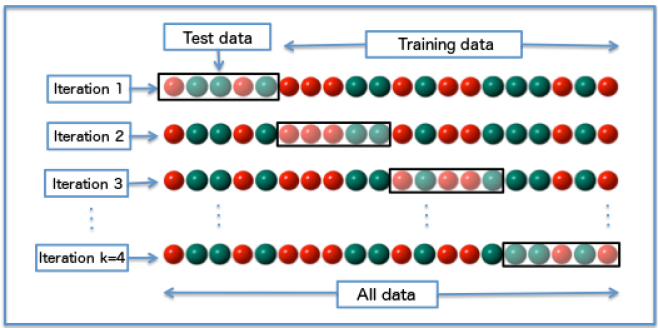

k-fold cross-validation (copyright Wikimedia foundation/Wikipedia)

# Patterns following the IoC principle

```
func CrossValidateKFold(k int,  // XXX: k is specific to this strategy
    sample []Data,
    evalTestAfterTraining func([]Data, []Data) Accuracy  // IoC
) Accuracy
```

- *Dependency Injection* (avoid a fixed cross-validation strategy):

`type Validator = func([]Data,`**`CrossValidator`**`) Accuracy`

- *Factory* (do not require the number of rounds of CV):

`type CrossValidator = func([]Data)` **`TestTrainSplitter`**

`var validate Validator`  
`accuracy := validate(sample,` **`NewKFold`**`(3))`

- *Generator* (*revert* the control by avoiding `evalTestAfterTraining`):

`type TestTrainSplitter = func(`**`*`**`[]Data,`**`*`**`[]Data)` **`bool`**

# Pass by value vs pass by reference

Example: Go slices are passed by value but their underlying data by reference

```
func NewKFold(k int) CrossValidator {
    return func(sample []Data) TestTrainSplitter {
        i, n := 0, (len(sample)+k-1)/k
        return func(testSet *[]Data, trainingSet *[]Data) bool {
            if i+n > len(sample) {
                n = len(sample) - i
            }
            *testSet = sample[i : i+n]
            *trainingSet = append(
                append([]Data(nil), sample[:i]...), sample[i+n:]...)
            i += n
            return i-n < len(sample)
        }
    }
}
```

- Python, Scala and R are **pass by value** *only*, but using *references*
  - **cannot reassign** variables passed as `testSet`/`testData` (must return new)
  - **R copies on mutation** (no true references except environments)

## Testing by example in Go

```
func Example3FoldCrossValidation() {
    cv := NewKFold(3)
    split := cv([]Data{10, 20, 30, 40, 50})
    var test, training []Data
    for split(&test, &training) {
        fmt.Println(test, training)
    }
    // Output:
    // [10 20] [30 40 50]
    // [30 40] [10 20 50]
    // [50] [10 20 30 40]
}
```

Output of `go -v test`:

```
=== RUN   Example3FoldCrossValidation
--- PASS: Example3FoldCrossValidation (0.00s)
ok      command-line-arguments  0.003s
```

*Note*: in **other languages** we need to write "boilerplate" code

- construct *expected* results as *data types*, and **compare them**

# Concurrency

Python:

- multi-threading is an **afterthought**, Python interpreter often waits on Global Interpreter Lock
- single-threaded *by design*, quoting the creator of Python:

  > It isn't Easy to Remove the GIL... I also don't expect it to go away until  
  > someone other than me goes through the effort of removing it,  
  > and showing that its removal doesn't slow down **single-threaded** Python code.

Go:

- concurrency is a *first-class* citizen
  - (I/O) **channels** to pass data among different goroutines
    - *unbuffered* (similar to UNIX pipes) or *unbuffered* (similar to queue)
  - **goroutine** use the *optimal* number of threads; **millions** run efficiently
    - more lightweight than thread, with faster context switching

# Intro task revisited: merging data sources

Suppose we want to analyze messages from **several** data sources:

1. Yelp reviews
2. Twitter posts
3. public Facebook posts

Example analyses:

- what are the keywords of hot topics (similar to earlier example)?
- who are the first users that mentioned something?
- how many users mentioned something on each day?

## Using Go *channels* for *data flow*

Interfaces for uniformly data access:

```
type Message interface {
    Text() string
    Timestamp() int64
    Author() string
}

type DataSource interface {
    Fetch(msgs chan<- Message)  // output channel
}
```

Analysis accepts messages as input and produces reports as output:

```
func analyze(msgQueue <-chan Message, reports chan<- Report) {
    for msg := range msgQueue {
        if ... {
            reports <- SummarizeData(...)
        }
    }
}
```

## Using Go *routines* for scalable data pipelines

```
// parallelize & merge data fetching (slow)
msgQueue := make(chan Message, 100)  // |buffer| = 100
for dataSource := range []DataSource{
    twitter.NewFetcher(),
    reddit.NewFetcher(),
    ...
} {                                // NOTE: "go" starts a goroutine
    go dataSource.Fetch(msgQueue)  //  and immediately returns
}

// concurrently run the analysis, creating reports
reports := make(chan string)  // unbuffered (always blocks)
go analyze(msgQueue, reports)

// collect reports (blocking)
for report := range reports {
    println(report)
}
```

- **parallelized** fetching
- **on-line** analysis may start *before* fetching finishes
- reports are printed on the fly, *as soon as* they are produced

# Recursion

E.g.: Using the operating system's API (function) for  
enumerating the contents (files and directories) of a directory (folder),  
**count** the files matching a certain criteria.

```
├── Private
│   └── secret
├── README.md
└── Work
    ├── Attorney-Smith_notes.txt
    ├── BusinessMeeting_2017-07-07.docx
    └── TODO
        ├── contact-partners
        └── handle-complaints
```

Natural solution (Python):

```
def count(dir, match):
    s = 0
    for entry in os.scandir(dir):  # 1 entry in memory at a time
        if entry.is_dir(follow_symlinks=False):
            s += count(entry.path, match)
        elif match(entry):
            s += 1
    return s
```

# Recursion (cont'd)

Solution (Go):

```
func count(d string, match func(os.FileInfo) bool) (s int64) {
    f, _ := os.Open(d)
    defer f.Close()
    for es, _ := f.Readdir(1); len(es) != 0; es, _ = f.Readdir(1) {
        entry := es[0]
        if entry.IsDir() {
            s += count(filepath.Join(d, entry.Name()), match)
        } else if match(entry) {
            s += 1
        }
    }
    return
}
```

## Limitations of recursion

- Many languages have a very limited stack size by default
  - Python raises `RecursionError` for >1000 nested (unfinished) function calls calls
    - e.g., consider `count` and path `subdir1/subdir2/.../subdir1001/matching-file`
  - 1024KB in Scala (assuming it runs on 64-bit Java 8)
- If an upper bound is known, recursion depth can be increased
  - dynamically (once the program is running)

    ```
    options(expressions=123456)  # R
    sys.setrecursionlimit(123456)  # Python
    ```

  - statically

    ```
    scala -J-Xss3g  # set to 3 GB
    ```

## Eliminating recursion using a state stack

A non-recursive `count` equivalent in Python:

```
def count(dir, match):
    s = 0
    stack = [(dir, os.scandir(dir))]
    while stack:
        dir, entry_iter = stack.pop()
        try:
            entry = next(entry_iter)
            if entry.is_dir():
                stack.append((entry.path, iter(os.scandir(entry.path))))
            elif match(entry):
                s += 1
            stack.append((dir, entry_iter))
        except StopIteration:
            pass
    return s
```

- Current state `(dir, entry_iter)` is pushed after next
  - effectively models a step in the `for` loop of the recursive `count`

# Benchmarking

## Complete source code in Go

```
func Fib(n int) int {
    if n < 2 {
        return n
    }
    return Fib(n-1) + Fib(n-2)
}

func BenchmarkFib(b *testing.B) {
    for _, bm := range []struct{ name string; n int }{
        {"base case (n=0)", 0}, {"base case (n=1)", 1},
        {"tiny n    (n=4)", 4}, {"small n   (n=8)", 8},
        {"medium n (n=16)", 16}, {"large n (n=32)", 32},
    } {
        b.Run(bm.name, func(b *testing.B) {
            for i := 0; i < b.N; i++ {
                Fib(bm.n)
            }
        })
    }
}
```

## Benchmark results

Output after running: `go test -bench=.`

```
goos: linux
goarch: amd64
BenchmarkFib/base_case_(n=0)-4          1000000000           2.28 ns/op
BenchmarkFib/base_case_(n=1)-4          1000000000           2.27 ns/op
BenchmarkFib/tiny_n___(n=4)-4           100000000           23.3 ns/op
BenchmarkFib/small_n__(n=8)-4           10000000           161 ns/op
BenchmarkFib/medium_n_(n=16)-4            200000          8197 ns/op
BenchmarkFib/large_n__(n=32)-4               100      16767897 ns/op
```

### Why benchmarking is easy in Go?

- Go *automatically* chooses the number of iterations (middle column, `b.N`)
- **normalized** time (per iteration) is reported
- implicit discovery, naming and reporting

# Relational databases

## SQLite (local & zero-configuration)

- **billions** of copies deployed; e.g., in:
  - *every* iOS (iPhone, iPad, etc.) and Android device
  - *every* Mac and Windows10 machine -most television sets and cable boxes
- storing which data?
  - Chrome, Firefox, Safari user data
  - Skype and Dropbox client metadata
  - iTunes, Apple notes, Acrobat Reader (PDF)

Source: https://www.sqlite.org/mostdeployed.html

## Scala SQLite setup in Ammonite shell

1. Load (auto-downloads & installs)

   ```
   interp.load.ivy("org.xerial" % "sqlite-jdbc" % "3.20.0")
   interp.load.ivy("org.slf4j" % "slf4j-nop" % "1.7.25")
   interp.load.ivy("com.typesafe.slick" % "slick" % "3.2.1")
   ```

2. Import

   ```
   import slick.driver.SQLiteDriver.api._
   import scala.concurrent._
   import scala.concurrent.duration._
   ```

3. Connect

   ```
   val db = Database.forURL("jdbc:sqlite:" +
       "path/to/file.sqlite"  /* or ":memory:" */,
       driver="org.sqlite.JDBC")
   ```

## Go SQLite setup using a 3rd-party driver

1. Install

   ```
   go get -u github.com/mattn/go-sqlite3
   ```

2. Load & Import

   ```
   import (
       "database/sql"
       . "context"
       . "time"
       _ "github.com/mattn/go-sqlite3"
   )
   ```

3. Connect

   ```
   db, err := sql.Open("DB-name",
       "path/to/file.sqlite"  /* or ":memory:" */)
   ```

## R SQLite setup using a 3rd-party driver

1. Install (auto-downloads)

   ```
   install.packages("RSQLite")
   ```

2. Load & Import

   ```
   library(RSQLite)
   ```

3. Connect

   ```
   db <- dbConnect(SQLite(),
       "path/to/file.sqlite") # or ":memory:"
   ```

## Querying Relational Data (with timeout)

Scala

```
try {
    val rows = Await(db.run(sql"""
        SELECT path,importCount,ignore FROM ImportHistory
        """.as[(String,Int,Double)], 2 seconds)
    for (row <- rows) println(row)
} catch { case e: TimeoutException =>
    // handle timeout
}
```

Go

```
ctx, cancel := WithTimeout(Background(), 2*Second); defer cancel()
rows := db.QueryContext(ctx, `
    SELECT path,importCount,ignore FROM ImportHistory`)
for rows.Next() {
    path, importCount, ignore := "", 0, false  // row := []interface{}
    rows.Scan(&path, &importCount, &ignore  /* or row */)
    fmt.Println(path, importCount, ignore   /* or row */)
}
rows.Close()
if ctx.Err() == DeadlineExceeded { /* handle timeout */ }
```

## Querying Relational Data (no timeout)

R

```
rows <- dbSendQuery(db, paste(sep="\n"
    "SELECT path,importCount,ignore FROM ImportHistory"
))
while (!dbHasCompleted(rows)) {
    row <- dbFetch(rows, n=1)
    cat(paste(df[1,], collapse=" "), "\n")
}
```

# Parsing & Serialization

- JSON (**J**ava**S**cript **O**bject **N**otation)
- XML (E**X**tensible **M**arkup **L**anguage)
- Custom (recursive) data

## JSON - *eager* parsing (all must fit in memory)

- in the standard library of
  - Python:

    ```
    import json
    with open("input.json") as file:
        objs = json.load(file)
    for i, obj = enumerate(objs):
        process(i, obj)
    ```

  - Go:

    ```
    import (
        "encoding/json"
        "io/ioutil"
    )
    ...
    objs := []interface{}
    contents , _ := ioutil.ReadFile("input.json")
    json.Unmarshal(contents, &objs)
    for i, obj := objs {
        process(i, obj)
    }
    ```

## JSON - *lazy* parsing

- Go provides an **incremental** parser:  
  e.g., useful for streaming JSON:

  ```
  var obj interface{}
  for d := json.NewDecoder(stream); d.Decode(&obj) == nil; obj = nil {
      process(obj)
  }
  ```

- the `stream` can be created by sending a request over the web:

  ```
  resp, _ := http.Get("http://read-json.net/today")
  stream := resp.Body
  ```

- the `stream` can also be established over a dedicated connection:

  ```
  conn, _ := net.Dial("tcp", "my.json-stream.server:1234")
  stream := bufio.NewReader(conn)
  ```

## JSON - out-of-the-box (de)serialization

Go:

```
type Message struct {
    Message string `json:msg`
    User string `json:user`
    Timestamp int64
}

var m Message
...
d.Decode(&m)
...
e.Encode(m)
```

## XML parsing via XPath

Example: Scrape university rankings at a team programming competition

- assuming the webpage HTML source code is a valid XML containing:

  ```
  <table id="medalTable">
    <tbody>
      <!-- rank are within <tr> ... <tr/> tags -->
    </tbody>
  </table>
  ```

Results of XPath query: `.//table[@id='medalTable']/tbody/tr"`

```
<tr><td class="rank">1</td>
    <td class="name">St. Petersburg State University</td>
    <td class="solved r11">11</td></tr>  <!-- (skipped) -->
<tr><td class="rank">3</td>
    <td class="name">Harvard University</td>
    <td class="solved r10">10</td></tr>  <!-- (skipped) -->
```

- in **Python standard library** (see also real-world code:
  - `github.com/losvald/univ-rank-scraper`

## XML parsing via XPath (cont'd)

- in fact, non-medalists are ranked in a separate table
- some of them solved the *same number* of problems but slower

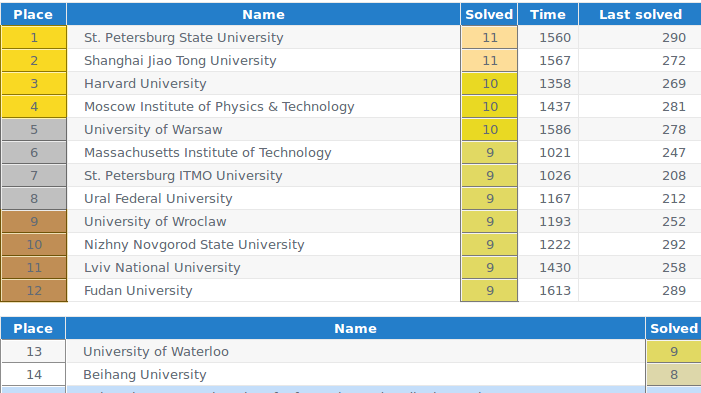

- XPath to find who solved 9 problems? `.//*[td[@class='solved r9']]`
  - returns **parents (`tr`)** of child tag `td` with matching attributes

## XML - out-of-the-box (de)serialization

Scala:

```
// serialization
case class Entry(rank: Int, name: String, solved: String)
val entries: Seq[Entry] = ...

for (Entry(rank, name, solved) <- entries) {
  // serialization as XML string
  val xml = <tr>
      <td class="rank">1</td>
      <td class="name">${name}</td>
      <td class="solved ${rank.toString}">${rank.toString}</td>
    </tr>

  // pattern matching XML to extraction each attribute
  for (<td class="{attr}">{text}</td> <- xml \ "td") {
    println(attr, text)
  }
}
```

# Custom parser for a person or relative

Mapping a mention to an entity:

- valid cases:
  - *my mom**'s** father*
  - *a child **of** Dan*
  - *uncle **of** grandfather **of** mom's niece*
- seemingly ambiguous but valid
  - *the son **of** Bob**'s** father* = *the son of [Bob's father]*
  - *my niece**'s** uncle**'s** nephew* = *[my niece's uncle]'s nephew*
  - *Tim Smith**,** Jr's father* = *[Tim Smith, Jr]'s father*
- invalid:
  - *Ted's father of brother*
  - *Bill of dad*
  - *my mom's John's son*

## Challenges of parsing a person or relative

E.g.: *father of mother of father of my Bob's uncle's sister's son*

- **recursive**ness of the data (arbitrary deep nesting):
- names may appear only at certain positions and at most once

Alternatives:

- write an ad-hoc parser by hand (tedious, hard to modify/evolve)
- cover only cases with a few *'s*/*of*s (incomplete, error-prone)

*Solution proposed*:

1. Write a **grammar**, e.g.: **P**arsing **E**xpression **G**rammar (PEG)
2. *automatically* **generate** a parser out of it using a library/tool

## A PEG of a person or relative

- *Base rules*:

**Name** ← `[A-Z]` `[a-z]*` (`[ ,]+` `[A-Z]` `[a-z]*`)`*`

**Member** ← (("an"/"a"/"the") _)? (Parent / Child  
Grandparent / Grandchild / Sibling / Nibling / Pibling)  
Parent ← !"step" ("parent"  
/ ("mother" / "mom" "my"?)  
/ ("father" / "daddy" / "dad"))  
Child ← "child" / "son" / "daughter"  
Grandchild ← "grand" Child  
Grandparent ← "grand" Parent  
Sibling ← !"step" ("bro" "ther"? / "sis" "ter"? / "sib" "ling"?)  
Nibling ← ("nephew" / "niece")  
Pibling ← ("aunt" / "uncle")

## A PEG of a person or relative (cont'd)

- *Top-level rule*:

Input ← **Person** !. *{NOTE: !. is End of Input (EOF)}*

- *Auxiliary rules:*

_ ← [ \t]+ *{NOTE: non-empty sequence of spaces and/or tabs}*  
S ← "*'s*"

- **Recursive** rules:

**Person** ← Member **Of** / Whose Member / Member / Name  
**Of** ← _ "of" _ ("mine" / **Person**)

Whose ← (("my" _)? Member / Name) S _ Whose0 / ("my" _)?  
**Whose0** ← Member S _ **Whose0** / &Member

*{NOTE:* Member *is matched at the end but not captured (*&*)}*

## How to work with a PEG parser in Go?

0. Install pigeon: `go get -u github.com/mna/pigeon`
1. Copy-paste the previous rules (without notes) into a `.peg` file:

   ```
   {
   package main  // Your Go code between {} will be left as is
   }
   // PEG RULES HERE ...
   ```

2. Generate a Go file that defines `Parse` method:

   ```
   pigeon -o parser.go parser.peg
   ```

3. Call `Parse` (needs an import if it is from a different package):

   ```
   result, err := Parse("", []byte(input))  // parse a string
   result, err := Parse(inputFile, nil)     // parse a file
   ```

## How to work with a PEG parser in Scala?

0. Load parboiled2 (`"org.parboiled" %% "parboiled" % "2.1.4"`)
1. Write PEG rules directly in Scala; **type-safe** but more *verbose*:

   ```
   import org.parboiled2._
   class FamilyParser(var input: ParserInput = "") extends Parser {
     def InputLine = rule { Person ~ EOI }
     // ... more rules ...
     def ` ` = rule { oneOrMore(ch(' ') | ch('\t')) }
     def Whose = rule { (optional("my"~` `)~Memb | Name)~S~` `~Whose0
                       | optional("my"~` `) }
     def Whose0: Rule0 = rule { Memb~S~` `~Whose0 | &(Memb) }
   }
   ```

2. Instantiate the parser, then run the top-level `InputLine` rule:

   ```
   val parser = new FamilyParser  // could give input as param
   parser.input = input; parser.InputLine.run() match {
     case Success(result) => ...                  }
   ```

## How to work with a PEG parser in Python?

0. Install parsimonious: `pip3 install parsimonious`
1. Write PEG rules as a Python string; might fail at *run-time*

   ```
   peg = """
       InputLine = Person
       # ... more rules ...
       _ = ~"[ \t]+"
       Whose = (("my" _)? Memb / Name) S _ Whose0 / ("my" _)?
       Whose0 = Member S _ Whose0 / &Memb
   """
   ```

2. Instantiate the parser, then parse one or more inputs

   ```
   from parsimonious.grammar import Grammar
   parser = Grammar(peg)      # MAY FAIL if invalid PEG
   result = grammar.parse(input)  # may raise exception
   ```